# Airbnb Pricing and Rating in Seattle in 2016

# - Business understanding

I'd like to answer three questions from the above datasets:

1. How many property types of airbnb and their price were in Seattle?
2. When to visit Seattle is most economy for family tourism living in airbnb?
3. Q3: Are reviews helpful for choosing airbnb?

# - Data understanding

```python
import numpy as np
import pandas as pd
import matplotlib.pyplot as plt
import seaborn as sns
import datetime as dt

%matplotlib inline
```

## 1. A Look at the Data

```python
calendar = pd.read_csv("../resources/calendar.csv")
listing = pd.read_csv("../resources/listings.csv")
reviews = pd.read_csv("../resources/reviews.csv")
```

## 1. calendar

### 1.1 Data Asssessment

```python
calendar.head()
```

|  | listing_id | date | available | price |
| --- | --- | --- | --- | --- |
| 0 | 241032 | 2016-01-04 | t | $85.00 |
| 1 | 241032 | 2016-01-05 | t | $85.00 |
| 2 | 241032 | 2016-01-06 | f | NaN |
| 3 | 241032 | 2016-01-07 | f | NaN |
| 4 | 241032 | 2016-01-08 | f | NaN |

```python
calendar.info()
```

```
<class 'pandas.core.frame.DataFrame'>
RangeIndex: 1393570 entries, 0 to 1393569
Data columns (total 4 columns):
listing_id    1393570 non-null int64
date          1393570 non-null object
available     1393570 non-null object
price         934542 non-null object
dtypes: int64(1), object(3)
memory usage: 42.5+ MB
```

```python
print("There are %i airbnb on the list." %calendar["listing_id"].unique().shape)
```

```
There are 3818 airbnb on the list.
```

```python
calendar[calendar["available"]=="t"].info()
```

```
<class 'pandas.core.frame.DataFrame'>
Int64Index: 934542 entries, 0 to 1393213
Data columns (total 4 columns):
listing_id    934542 non-null int64
date          934542 non-null object
available     934542 non-null object
price         934542 non-null object
dtypes: int64(1), object(3)
memory usage: 35.6+ MB
```

```python
calendar[calendar["available"]=="f"].info()
```

```
<class 'pandas.core.frame.DataFrame'>
Int64Index: 459028 entries, 2 to 1393569
Data columns (total 4 columns):
listing_id    459028 non-null int64
date          459028 non-null object
available     459028 non-null object
price         0 non-null object
dtypes: int64(1), object(3)
memory usage: 17.5+ MB
```

```python
print("Since:",calendar["date"].min(),"\n Due:",calendar["date"].max())
```

```
Since: 2016-01-04
 Due: 2017-01-02
```

### **Assessment conclusion:**

- The data set of Calendar records 3818 airbnbs price information for 2016 entile year.
- There isn't price information when a bnb is not available.
- The need of data wrangling：
  - data type: the data type of data to be date
  - binary data: map t for True and f for False
  - price: delet currency symbol and change data type to float.
- Vacancy value could be driven to a new set, then merge to listing.

### 1.2 Data Clean

- add a column named month

```python
# change the data types
calendar["date"] = pd.to_datetime(calendar["date"])
calendar["available"] = calendar["available"].map({"t": True,
                                                   "f": False})
calendar["price"] = calendar["price"].str.replace(",","").str.replace("$","").astype(float)

# del datum when bnbs are not available
#calendar = calendar[calendar["available"]].drop("available",axis=1)

# sadd a column named month,elect data in 2016
calendar = calendar[calendar["date"] <= dt.datetime(2016,12,31)]
calendar["month"] = calendar["date"].apply(lambda x: x.month).astype(str)
```

### **Possible question:**

- available rate
- price changes in every month
- highest price and lowest price

## 2 listing

### 2.1 Initial Data Asssessment

#### - Shape

```python
listing.shape
```

```
(3818, 92)
```

#### - unique value

```python
unique_col_ind = np.argwhere(np.array([listing.iloc[:,i].unique().shape[0] for i in range(listing.shape[1])])==1).flatten()
listing.iloc[:,unique_col_ind].head()
```

|  | scrape_id | last_scraped | experiences_offered | market | country_code | country | has_availability | calendar_last_scraped | requires_license | license | jurisdiction_names |
| --- | --- | --- | --- | --- | --- | --- | --- | --- | --- | --- | --- |
| 0 | 20160104002432 | 2016-01-04 | none | Seattle | US | United States | t | 2016-01-04 | f | NaN | WASHINGTON |
| 1 | 20160104002432 | 2016-01-04 | none | Seattle | US | United States | t | 2016-01-04 | f | NaN | WASHINGTON |
| 2 | 20160104002432 | 2016-01-04 | none | Seattle | US | United States | t | 2016-01-04 | f | NaN | WASHINGTON |
| 3 | 20160104002432 | 2016-01-04 | none | Seattle | US | United States | t | 2016-01-04 | f | NaN | WASHINGTON |
| 4 | 20160104002432 | 2016-01-04 | none | Seattle | US | United States | t | 2016-01-04 | f | NaN | WASHINGTON |

#### - missing data

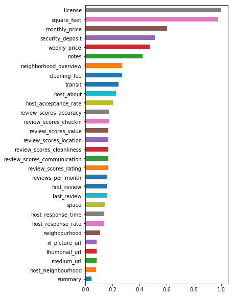

```python
listing.isnull().mean().sort_values(ascending=True)[-30:].plot.barh(figsize=(5,10));
```

#### - urls

```python
url_col_ind = np.argwhere([("url" in i) for i in listing.columns]).flatten()
listing.iloc[:,url_col_ind].head()
```

|  | listing_url | thumbnail_url | medium_url | picture_url | xl_picture_url | host_url | host_thumbnail_url | host_picture_url |
| --- | --- | --- | --- | --- | --- | --- | --- | --- |
| 0 | https://www.airbnb.com/rooms/241032 | NaN | NaN | https://a1.muscache.com/ac/pictures/67560560/c... | NaN | https://www.airbnb.com/users/show/956883 | https://a0.muscache.com/ac/users/956883/profil... | https://a0.muscache.com/ac/users/956883/profil... |
| 1 | https://www.airbnb.com/rooms/953595 | https://a0.muscache.com/ac/pictures/14409893/f... | https://a0.muscache.com/im/pictures/14409893/f... | https://a0.muscache.com/ac/pictures/14409893/f... | https://a0.muscache.com/ac/pictures/14409893/f... | https://www.airbnb.com/users/show/5177328 | https://a0.muscache.com/ac/users/5177328/profi... | https://a0.muscache.com/ac/users/5177328/profi... |
| 2 | https://www.airbnb.com/rooms/3308979 | NaN | NaN | https://a2.muscache.com/ac/pictures/b4324e0f-a... | NaN | https://www.airbnb.com/users/show/16708587 | https://a1.muscache.com/ac/users/16708587/prof... | https://a1.muscache.com/ac/users/16708587/prof... |
| 3 | https://www.airbnb.com/rooms/7421966 | NaN | NaN | https://a0.muscache.com/ac/pictures/94146944/6... | NaN | https://www.airbnb.com/users/show/9851441 | https://a2.muscache.com/ac/users/9851441/profi... | https://a2.muscache.com/ac/users/9851441/profi... |
| 4 | https://www.airbnb.com/rooms/278830 | NaN | NaN | https://a1.muscache.com/ac/pictures/6120468/b0... | NaN | https://www.airbnb.com/users/show/1452570 | https://a0.muscache.com/ac/users/1452570/profi... | https://a0.muscache.com/ac/users/1452570/profi... |

```python
listing.iloc[:,url_col_ind].info()
```

```
<class 'pandas.core.frame.DataFrame'>
RangeIndex: 3818 entries, 0 to 3817
Data columns (total 8 columns):
listing_url           3818 non-null object
thumbnail_url         3498 non-null object
medium_url            3498 non-null object
picture_url           3818 non-null object
xl_picture_url        3498 non-null object
host_url              3818 non-null object
host_thumbnail_url    3816 non-null object
host_picture_url      3816 non-null object
dtypes: object(8)
memory usage: 238.7+ KB
```

```python
listing.loc[1,"host_picture_url"]
```

```
'https://a0.muscache.com/ac/users/5177328/profile_pic/1361540767/original.jpg?interpolation=lanczos-none&crop=w:w;*,*&crop=h:h;*,*&resize=225:*&output-format=jpg&output-quality=70'
```

### 2.2 Initial Data Clean

- drop 11 unique value features
- drop 6 features with missing values exceeding 40%
- create a feature named linked_to_media while dropping 8 url features
- del name and host_name

```python
# unique features
listing_col = listing.columns.values
listing.drop(listing_col[unique_col_ind], axis=1, inplace=True)

# missing values
listing_col = listing.columns.values
missingValue_col_ind = np.argwhere(listing.isnull().mean() > 0.4).flatten()
listing.drop(listing_col[missingValue_col_ind],axis=1, inplace=True)

# urls
listing_col = listing.columns.values
listing["linked_to_media"] = listing["thumbnail_url"].notnull()
url_col_ind = np.argwhere([("url" in i) for i in listing.columns]).flatten()
listing.drop(listing_col[url_col_ind], axis=1, inplace=True)

# del name and host_name
listing.drop(["name","host_name"],axis=1,inplace=True)
```

### 2.3 2nd Data Assessment -- objective datum

```python
listing.select_dtypes(include=["object"]).iloc[0:3,1:6]
```

|  | space | description | neighborhood_overview | transit | host_since |
| --- | --- | --- | --- | --- | --- |
| 0 | Make your self at home in this charming one-be... | Make your self at home in this charming one-be... | NaN | NaN | 2011-08-11 |
| 1 | Beautiful, hypoallergenic apartment in an extr... | Chemically sensitive? We've removed the irrita... | Queen Anne is a wonderful, truly functional vi... | Convenient bus stops are just down the block, ... | 2013-02-21 |
| 2 | Our house is modern, light and fresh with a wa... | New modern house built in 2013. Spectacular s... | Upper Queen Anne is a charming neighborhood fu... | A bus stop is just 2 blocks away. Easy bus a... | 2014-06-12 |

```python
listing.select_dtypes(include=["object"]).iloc[:5,6:18]
```

|  | host_location | host_about | host_response_time | host_response_rate | host_acceptance_rate | host_is_superhost | host_neighbourhood | host_verifications | host_has_profile_pic | host_identity_verified | street | neighbourhood |
| --- | --- | --- | --- | --- | --- | --- | --- | --- | --- | --- | --- | --- |
| 0 | Seattle, Washington, United States | I am an artist, interior designer, and run a s... | within a few hours | 96% | 100% | f | Queen Anne | ['email', 'phone', 'reviews', 'kba'] | t | t | Gilman Dr W, Seattle, WA 98119, United States | Queen Anne |
| 1 | Seattle, Washington, United States | Living east coast/left coast/overseas. Time i... | within an hour | 98% | 100% | t | Queen Anne | ['email', 'phone', 'facebook', 'linkedin', 're... | t | t | 7th Avenue West, Seattle, WA 98119, United States | Queen Anne |
| 2 | Seattle, Washington, United States | i love living in Seattle. i grew up in the mi... | within a few hours | 67% | 100% | f | Queen Anne | ['email', 'phone', 'google', 'reviews', 'jumio'] | t | t | West Lee Street, Seattle, WA 98119, United States | Queen Anne |
| 3 | Seattle, Washington, United States | NaN | NaN | NaN | NaN | f | Queen Anne | ['email', 'phone', 'facebook', 'reviews', 'jum... | t | t | 8th Avenue West, Seattle, WA 98119, United States | Queen Anne |
| 4 | Seattle, Washington, United States | Hi, I live in Seattle, Washington but I'm orig... | within an hour | 100% | NaN | f | Queen Anne | ['email', 'phone', 'facebook', 'reviews', 'kba'] | t | t | 14th Ave W, Seattle, WA 98119, United States | Queen Anne |

```python
listing.select_dtypes(include=["object"]).iloc[:5,18:27]
```

|  | neighbourhood_cleansed | neighbourhood_group_cleansed | city | state | zipcode | smart_location | is_location_exact | property_type | room_type |
| --- | --- | --- | --- | --- | --- | --- | --- | --- | --- |
| 0 | West Queen Anne | Queen Anne | Seattle | WA | 98119 | Seattle, WA | t | Apartment | Entire home/apt |
| 1 | West Queen Anne | Queen Anne | Seattle | WA | 98119 | Seattle, WA | t | Apartment | Entire home/apt |
| 2 | West Queen Anne | Queen Anne | Seattle | WA | 98119 | Seattle, WA | t | House | Entire home/apt |
| 3 | West Queen Anne | Queen Anne | Seattle | WA | 98119 | Seattle, WA | t | Apartment | Entire home/apt |
| 4 | West Queen Anne | Queen Anne | Seattle | WA | 98119 | Seattle, WA | t | House | Entire home/apt |

```python
listing.select_dtypes(include=["object"]).iloc[:5,27:34]
```

|  | bed_type | amenities | price | cleaning_fee | extra_people | calendar_updated | first_review |
| --- | --- | --- | --- | --- | --- | --- | --- |
| 0 | Real Bed | {TV,"Cable TV",Internet,"Wireless Internet","A... | $85.00 | NaN | $5.00 | 4 weeks ago | 2011-11-01 |
| 1 | Real Bed | {TV,Internet,"Wireless Internet",Kitchen,"Free... | $150.00 | $40.00 | $0.00 | today | 2013-08-19 |
| 2 | Real Bed | {TV,"Cable TV",Internet,"Wireless Internet","A... | $975.00 | $300.00 | $25.00 | 5 weeks ago | 2014-07-30 |
| 3 | Real Bed | {Internet,"Wireless Internet",Kitchen,"Indoor ... | $100.00 | NaN | $0.00 | 6 months ago | NaN |
| 4 | Real Bed | {TV,"Cable TV",Internet,"Wireless Internet",Ki... | $450.00 | $125.00 | $15.00 | 7 weeks ago | 2012-07-10 |

```python
listing.select_dtypes(include=["object"]).iloc[:5,34:]
```

|  | last_review | instant_bookable | cancellation_policy | require_guest_profile_picture | require_guest_phone_verification |
| --- | --- | --- | --- | --- | --- |
| 0 | 2016-01-02 | f | moderate | f | f |
| 1 | 2015-12-29 | f | strict | t | t |
| 2 | 2015-09-03 | f | strict | f | f |
| 3 | NaN | f | flexible | f | f |
| 4 | 2015-10-24 | f | strict | f | f |

```python
listing["bed_type"].value_counts()
```

```
Real Bed         3657
Futon              74
Pull-out Sofa      47
Airbed             27
Couch              13
Name: bed_type, dtype: int64
```

```python
(listing["require_guest_profile_picture"] == listing["require_guest_phone_verification"]).value_counts()
```

```
True     3736
False      82
dtype: int64
```

**Assessment conclusion**

### 2.4 2nd Data Clean

**descriptive:**

- del summary,space,neighborhood_overview, notes and transit

```python
listing = listing.drop(["summary","space","description","neighborhood_overview","transit"],axis=1)
```

**host characteristics:**

- del host_about,host_neighbourhood,host_acceptance_rate,host_verifications,host_has_profile_pic
- change date types of host_response_rate and host_acceptance_rate to numerate
- change host_since to host_owned_years
- change host_location to host_live_in_seattle
- change date types of host_is_superhost to binary

```python
# del host_about,host_neighbourhood,host_acceptance_rate,host_verifications,host_has_profile_pic
listing = listing.drop(["host_about","host_neighbourhood","host_acceptance_rate","host_verifications","host_has_profile_pic"],axis=1)

# change date types of host_response_rate and host_acceptance_rate to numerate
listing["host_response_rate"] = listing["host_response_rate"].str.split("%").str[0].astype(float)/100

# change host_since to host_owned_years
listing["host_since"]=[round((dt.datetime(2016,1,4) - pd.to_datetime(listing["host_since"][i])).days/365.25,2) for i in range(listing.shape[0])]
listing = listing.rename(columns={"host_since":"host_owned_years"})

# change host_location to host_live_in_seattle
listing["host_location"] = listing["host_location"].apply(lambda x: np.nan if str(x) == "nan" else "seattle" in x.lower())
listing = listing.rename(columns={"host_location": "host_live_in_seattle"})

# change date types of host_is_superhost to binary
listing["host_is_superhost"] = listing["host_is_superhost"].map({"f": False,
                                                                 "t": True})
listing["host_is_superhost"] = listing["host_is_superhost"].astype(bool)
```

**location:**

- del street,neighbourhood,neighbourhood_cleansed,city,state,zipcode,smart_location,latitude and longitud
- change the data type of is_location_exact to bool

```python
# del street,neighbourhood,neighbourhood_cleansed,city,state,zipcode,smart_location,latitude and longitud
listing = listing.drop(["street","neighbourhood","neighbourhood_cleansed",
                        "city","state","zipcode","smart_location"],axis=1)

# change the data type of is_location_exact to bool
listing["is_location_exact"] = listing["is_location_exact"].map({"f": False,
                                                                 "t": True})
listing["is_location_exact"] = listing["is_location_exact"].astype(bool)
```

**airbnb characteristics:**

- drop amenities
- change the data type of the prices to be numerical

```python
# drop amenities
listing = listing.drop(["amenities"],axis=1)

# change the data type of the prices to be numerical
prices = ["price","cleaning_fee","extra_people"]

for col in prices:
    listing[col] = listing[col].str.replace("$","").str.replace(",","").astype(float)
```

**review records**

- del all

```python
listing = listing.drop(["calendar_updated","first_review","last_review"],axis=1)
```

**booking requirement:**

- del require_guest_phone_verification
- change data type of instant_bookable and require_guest_profile_picture to bool

```python
# del require_guest_phone_verification
listing = listing.drop(["require_guest_phone_verification"],axis=1)

# change data type of instant_bookable and require_guest_profile_picture to bool
for i in ["instant_bookable","require_guest_profile_picture"]:
    listing[i] = listing[i].map({"f": False, "t": True}).astype(bool)
```

### 2.5 3rd Data Assessment -- numerical data

```python
listing.select_dtypes(exclude=["object","bool"]).iloc[:5,:10]
```

|  | id | host_id | host_owned_years | host_response_rate | host_listings_count | host_total_listings_count | latitude | longitude | accommodates | bathrooms |
| --- | --- | --- | --- | --- | --- | --- | --- | --- | --- | --- |
| 0 | 241032 | 956883 | 4.40 | 0.96 | 3.0 | 3.0 | 47.636289 | -122.371025 | 4 | 1.0 |
| 1 | 953595 | 5177328 | 2.87 | 0.98 | 6.0 | 6.0 | 47.639123 | -122.365666 | 4 | 1.0 |
| 2 | 3308979 | 16708587 | 1.56 | 0.67 | 2.0 | 2.0 | 47.629724 | -122.369483 | 11 | 4.5 |
| 3 | 7421966 | 9851441 | 2.16 | NaN | 1.0 | 1.0 | 47.638473 | -122.369279 | 3 | 1.0 |
| 4 | 278830 | 1452570 | 4.10 | 1.00 | 2.0 | 2.0 | 47.632918 | -122.372471 | 6 | 2.0 |

```python
(listing["host_listings_count"]-listing["host_total_listings_count"]).value_counts()
```

```
0.0    3816
dtype: int64
```

```python
listing.select_dtypes(exclude=["object","bool"]).iloc[:5,10:20]
```

|  | bedrooms | beds | price | cleaning_fee | guests_included | extra_people | minimum_nights | maximum_nights | availability_30 | availability_60 |
| --- | --- | --- | --- | --- | --- | --- | --- | --- | --- | --- |
| 0 | 1.0 | 1.0 | 85.0 | NaN | 2 | 5.0 | 1 | 365 | 14 | 41 |
| 1 | 1.0 | 1.0 | 150.0 | 40.0 | 1 | 0.0 | 2 | 90 | 13 | 13 |
| 2 | 5.0 | 7.0 | 975.0 | 300.0 | 10 | 25.0 | 4 | 30 | 1 | 6 |
| 3 | 0.0 | 2.0 | 100.0 | NaN | 1 | 0.0 | 1 | 1125 | 0 | 0 |
| 4 | 3.0 | 3.0 | 450.0 | 125.0 | 6 | 15.0 | 1 | 1125 | 30 | 60 |

```python
listing.select_dtypes(exclude=["object","bool"]).iloc[:5,20:]
```

|  | availability_90 | availability_365 | number_of_reviews | review_scores_rating | review_scores_accuracy | review_scores_cleanliness | review_scores_checkin | review_scores_communication | review_scores_location | review_scores_value | calculated_host_listings_count | reviews_per_month |
| --- | --- | --- | --- | --- | --- | --- | --- | --- | --- | --- | --- | --- |
| 0 | 71 | 346 | 207 | 95.0 | 10.0 | 10.0 | 10.0 | 10.0 | 9.0 | 10.0 | 2 | 4.07 |
| 1 | 16 | 291 | 43 | 96.0 | 10.0 | 10.0 | 10.0 | 10.0 | 10.0 | 10.0 | 6 | 1.48 |
| 2 | 17 | 220 | 20 | 97.0 | 10.0 | 10.0 | 10.0 | 10.0 | 10.0 | 10.0 | 2 | 1.15 |
| 3 | 0 | 143 | 0 | NaN | NaN | NaN | NaN | NaN | NaN | NaN | 1 | NaN |
| 4 | 90 | 365 | 38 | 92.0 | 9.0 | 9.0 | 10.0 | 10.0 | 9.0 | 9.0 | 1 | 0.89 |

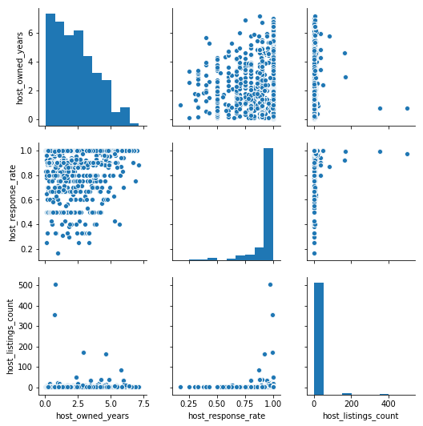

```python
listing_num_host = listing[["host_owned_years","host_response_rate","host_listings_count"]].dropna()
sns.pairplot(listing_num_host);
```

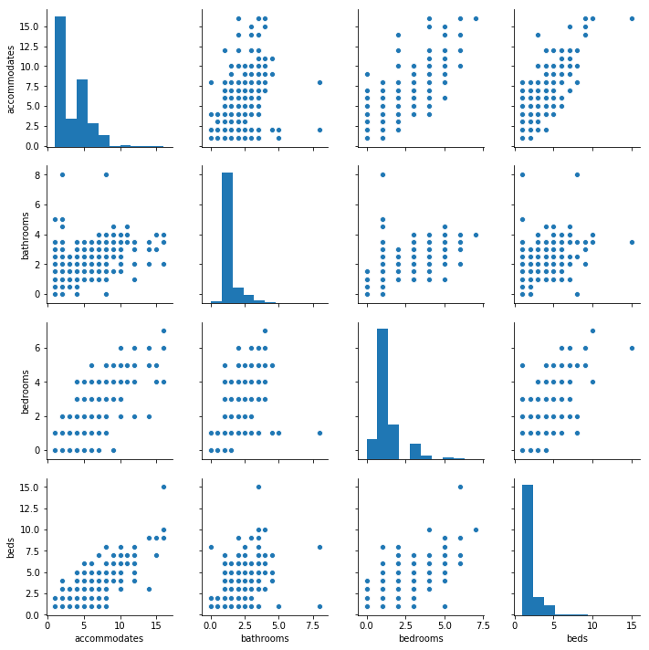

```python
listing_num_accom = listing[["accommodates","bathrooms","bedrooms","beds"]].dropna()
sns.pairplot(listing_num_accom);
```

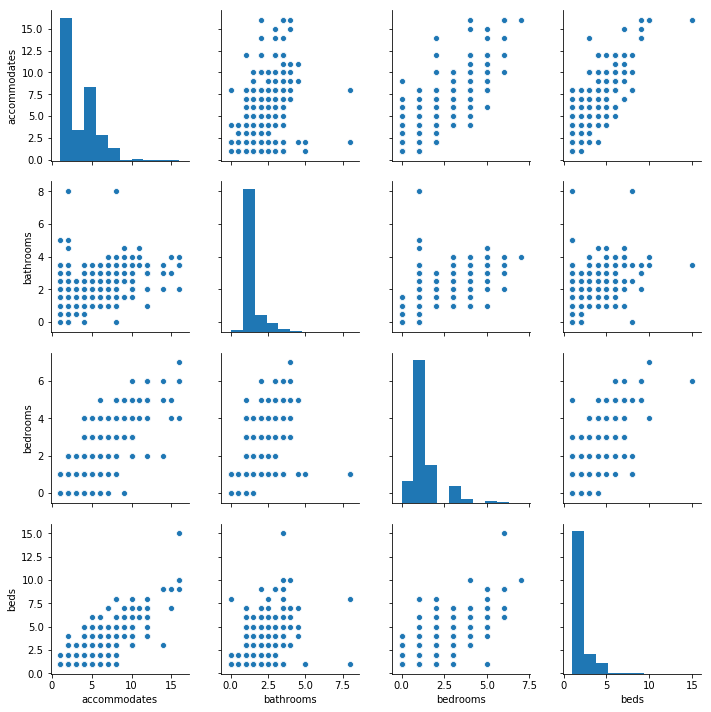

```python
listing_num_price = listing[["number_of_reviews","cleaning_fee","guests_included","extra_people"]].dropna()
sns.pairplot(listing_num_accom);
```

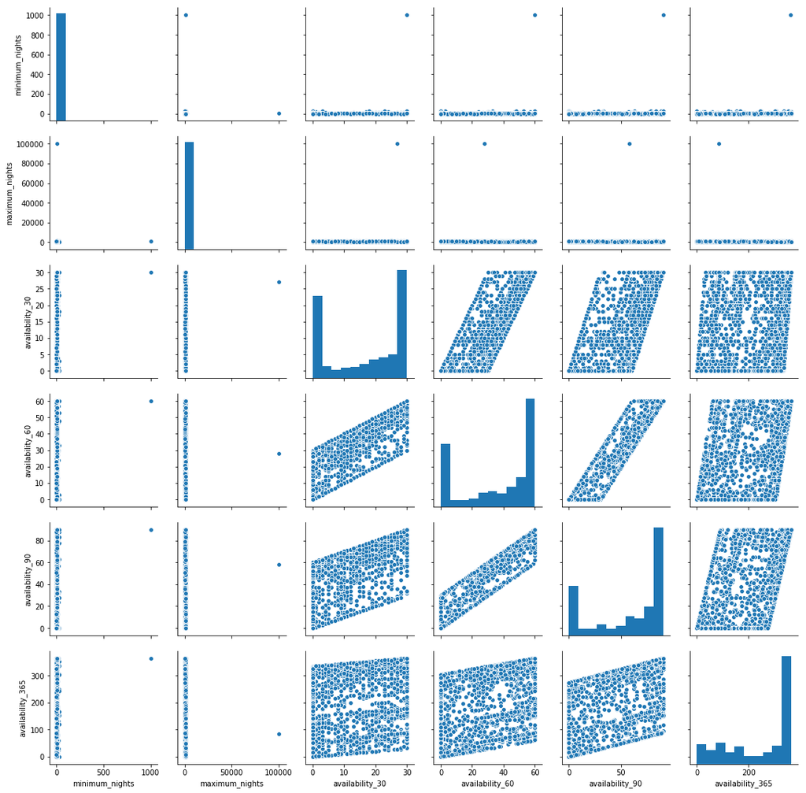

```python
listing_num_cond = listing[["minimum_nights",
                            "maximum_nights",
                            "availability_30",
                            "availability_60",
                            "availability_90",
                            "availability_365"]].dropna()
sns.pairplot(listing_num_cond);
```

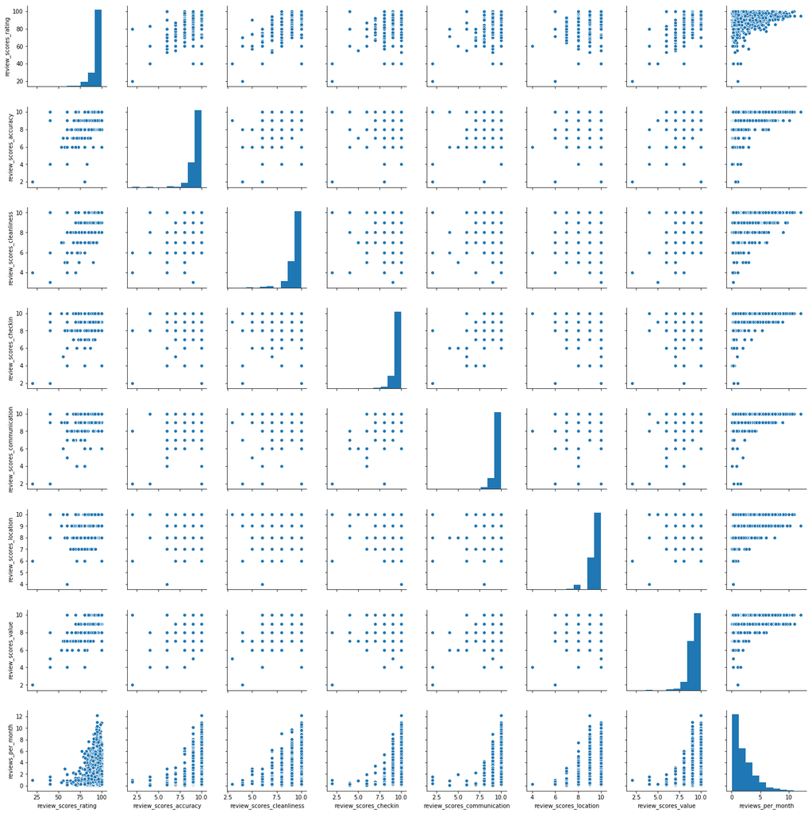

```python
listing_num_reviews = listing[["review_scores_rating",
                               "review_scores_accuracy",
                               "review_scores_cleanliness",
                               "review_scores_checkin",
                               "review_scores_communication",
                               "review_scores_location",
                               "review_scores_value",
                               "reviews_per_month"]].dropna()
sns.pairplot(listing_num_reviews);
```

**Assessment conclusion:**

There are 6 parts in the numerate data similar to non-numerate features. They are:

```
1. host
2. location
3. accommodation
4. price
5. rent condition
6. reviews
```

For the **host part**, it records host_owned_years,host_response_rate,host_listings_count,and host_listings_count(it deplicated to host_listings_total_count should be deleted). There is no relation among them.

**Location** is GPS position which conveys similar information to neighbourhood_group_cleansed. So I don't like to using these features.

Data of accomodation suggests airbnbs are all small business with high kurtosis and positive skewness. They are all positive correlated. More accommodats, more bedrooms, beds and bathrooms. That's reasonable.

Prices are positive correlated. However, total cost customer paid should include cleaning_fee into the price.

In condition parts:

```
- minimum_nights: 99% airbnbs require minimum nights less than 1 week.
- minimum_nights: most datum locate 7,14,30,60,90,365 and 1125. They are 1 week, 2 weeks, 1 month, 2 monthes, 1 season, 1 year and 3 years.
- avaiability means how many days available in 30/60/90/365 days. They are highly correlated. However only 30 days is meaningful, because most values of difference between availability of 30 and 60 are concentrated at 30 and 0.
```

In review parts:

- review socre is conposed by 6 parts. They are accuracy, cleanliness, checkin, communication, location and value.
- frequency of review is irrelative to review socores whereas it could be infer whether the bnb is hot.

### 2.6 3nd Data clean

- del host_total_listings_count, latitude, longitude, availability_60, availability_90,availability_365
- clean fee added to price

```python
# del host_total_listings_count, availability_60, availability_90,availability_365
listing = listing.drop(["host_total_listings_count",
                        "availability_60",
                        "availability_90",
                        "availability_365"], axis=1)

# clean fee added to price
listing["price"] = (listing["price"] + listing["cleaning_fee"].fillna(0))
listing.drop("cleaning_fee", axis=1, inplace=True)
```

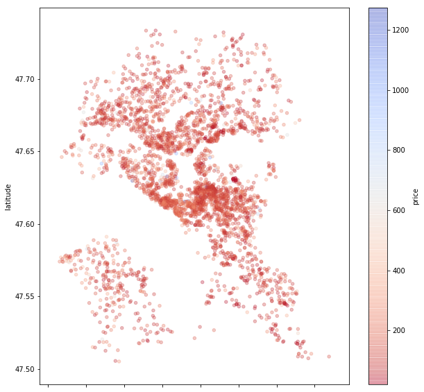

```python
listing[["longitude","latitude","price"]].plot.scatter(x="longitude",y="latitude",
                                                       c="price",cmap=plt.cm.coolwarm_r, alpha=0.3,
                                                       figsize=(10,10));
```

## 3 reviews

### 3.1 Have a look

```python
reviews.info()
```

```
<class 'pandas.core.frame.DataFrame'>
RangeIndex: 84849 entries, 0 to 84848
Data columns (total 6 columns):
listing_id       84849 non-null int64
id               84849 non-null int64
date             84849 non-null object
reviewer_id      84849 non-null int64
reviewer_name    84849 non-null object
comments         84831 non-null object
dtypes: int64(3), object(3)
memory usage: 3.9+ MB
```

```python
reviews.head()
```

|  | listing_id | id | date | reviewer_id | reviewer_name | comments |
| --- | --- | --- | --- | --- | --- | --- |
| 0 | 7202016 | 38917982 | 2015-07-19 | 28943674 | Bianca | Cute and cozy place. Perfect location to every... |
| 1 | 7202016 | 39087409 | 2015-07-20 | 32440555 | Frank | Kelly has a great room in a very central locat... |
| 2 | 7202016 | 39820030 | 2015-07-26 | 37722850 | Ian | Very spacious apartment, and in a great neighb... |
| 3 | 7202016 | 40813543 | 2015-08-02 | 33671805 | George | Close to Seattle Center and all it has to offe... |
| 4 | 7202016 | 41986501 | 2015-08-10 | 34959538 | Ming | Kelly was a great host and very accommodating ... |

### 3.2 Data Clean

```python
reviews["date"] = pd.to_datetime(reviews["date"])
```

# Question 1: How many property types of airbnb and their price were in Seattle?

## 1. Prepare Data

### 1.1 Data Gathering

```python
q1 = listing.copy()
q1.drop(["id","host_id","latitude","longitude"],axis=1,inplace=True)
```

### 1.2 Handle categorical and missing data

**- Handle categorical data**

```python
for col in q1.select_dtypes(include=["O"]).columns:
    try:
        if q1[col].dropna().unique().shape[0] <= 2:
            q1 = pd.concat([q1.drop(col,axis=1),
                            pd.get_dummies(q1[col], prefix=col, prefix_sep="_",drop_first=True, dummy_na=False)],axis=1)
        else:
            q1 = pd.concat([q1.drop(col,axis=1),
                            pd.get_dummies(q1[col], prefix=col, prefix_sep="_",drop_first=False, dummy_na=False)],axis=1)
    except:
        continue
```

#### - Handle missing data

```python
q1.drop(["review_scores_accuracy",
         "review_scores_cleanliness",
         "review_scores_checkin",
         "review_scores_communication",
         "review_scores_location",
         "review_scores_value"],axis=1, inplace=True)
```

```python
q1 = q1.dropna(axis=0)
```

## 2. Analyze, Model, and Visualize

```python
y = q1["price"]
X= q1.drop("price",axis=1)
```

```python
from sklearn.model_selection import train_test_split
from sklearn.metrics import r2_score
X_train, X_test, y_train, y_test = train_test_split(X,y)
```

```python
from sklearn.ensemble import RandomForestRegressor
rf_model = RandomForestRegressor()
rf_model.fit(X_train, y_train)
```

```
RandomForestRegressor(bootstrap=True, criterion='mse', max_depth=None,
           max_features='auto', max_leaf_nodes=None,
           min_impurity_decrease=0.0, min_impurity_split=None,
           min_samples_leaf=1, min_samples_split=2,
           min_weight_fraction_leaf=0.0, n_estimators=10, n_jobs=1,
           oob_score=False, random_state=None, verbose=0, warm_start=False)
```

```python
pred = rf_model.predict(X_test)
round(r2_score(pred,y_test),2)
```

```
0.65
```

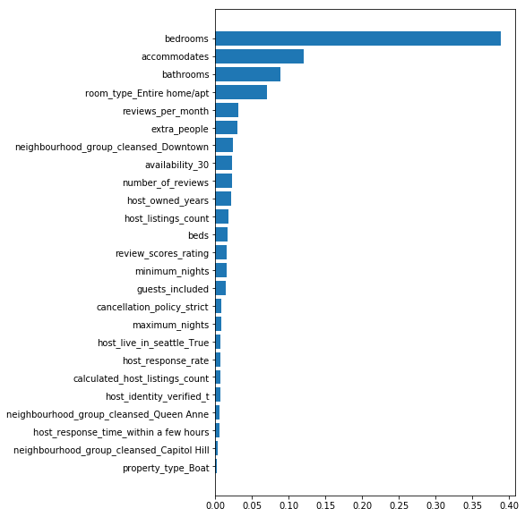

```python
important = np.argsort(rf_model.feature_importances_)
plt.figure(figsize=(6,10))
plt.barh(y=range(25),width=rf_model.feature_importances_[important][-25:])
plt.yticks(range(25), X.columns[important][-25:]);
```

```python
from sklearn.linear_model import LinearRegression
lr_model = LinearRegression()
lr_model.fit(X_train, y_train)
```

```
LinearRegression(copy_X=True, fit_intercept=True, n_jobs=1, normalize=False)
```

```python
pred = lr_model.predict(X_test)
round(r2_score(pred,y_test),2)
```

```
0.65
```

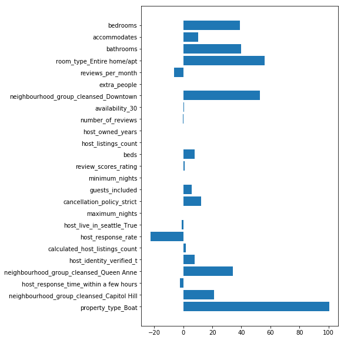

```python
plt.figure(figsize=(6,10))
plt.barh(y=range(25),width=lr_model.coef_[important][-25:])
plt.yticks(range(25), X.columns[important][-25:]);
```

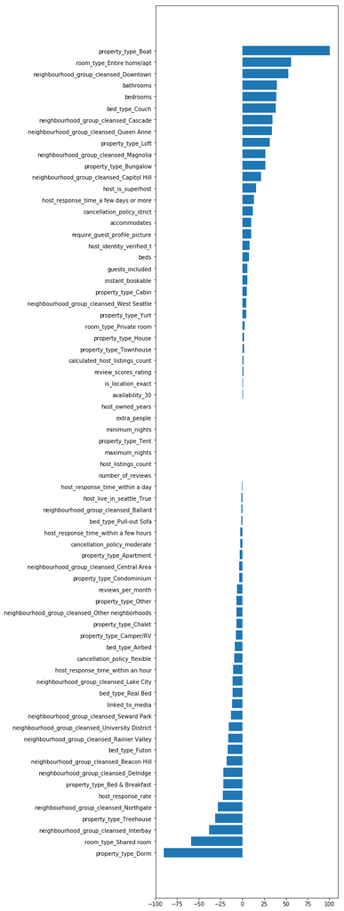

```python
ind = np.argsort(lr_model.coef_)
plt.figure(figsize=(6,30))
plt.barh(y=range(X.shape[1]),width=lr_model.coef_[ind])
plt.yticks(range(X.shape[1]),X.columns[ind]);
```

### Conclusion:

I set models of random forest and linear regression to observe what features are more important to price and what features' correlation to price. Unfortunately, the scores of the models are not good enough and unstable. However, the results are stable. They show roughly the relationship between price and features. Thereful, I'd to dig the relationship more directly.

## Q1_1: property types and price

### 1_1.1 Prepare Data

```python
q1_1 = listing.copy()[["id","property_type","room_type","price","accommodates","neighbourhood_group_cleansed"]]
```

### 1-1.2 Analyze, Model, and Visualize

```python
print(plt.style.available)
```

```
['seaborn-dark', 'seaborn-darkgrid', 'seaborn-ticks', 'fivethirtyeight', 'seaborn-whitegrid', 'classic', '_classic_test', 'fast', 'seaborn-talk', 'seaborn-dark-palette', 'seaborn-bright', 'seaborn-pastel', 'grayscale', 'seaborn-notebook', 'ggplot', 'seaborn-colorblind', 'seaborn-muted', 'seaborn', '…
```

#### - Average Price

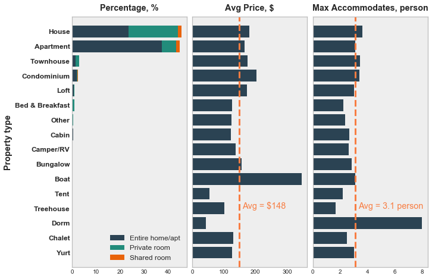

```python
plt.style.use("seaborn-white")

prop_types = q1_1.groupby(["property_type","room_type"]).count()["id"]
prop_types = prop_types.apply(lambda x: x/prop_types.sum()*100).reset_index()
prop_types = pd.pivot_table(prop_types, index="property_type",columns="room_type",values="id")
ind = np.argsort(prop_types.sum(axis=1))
types_plot =  prop_types.iloc[ind,:]

price_plot = q1_1.groupby("property_type").mean()["price"].round(2)[ind]
accom_plot = q1_1.groupby("property_type").mean()["accommodates"].round(2)[ind]

plt.style.use("bmh")
fig,(ax1,ax2,ax3) = plt.subplots(ncols=3,figsize=(10,6))
fig.subplots_adjust(top=1.1, left=0.07, right=0.9,
                        hspace=0.5, wspace=0.05)

ax1.barh(y= range(ind.shape[0]), width = types_plot.iloc[:,0],color="#2b4353",align='center')
ax1.barh(y= range(ind.shape[0]), width = types_plot.iloc[:,1],left=types_plot.iloc[:,0],color="#228c7b",align='center')
ax1.barh(y= range(ind.shape[0]), width = types_plot.iloc[:,2],left=types_plot.iloc[:,0] + types_plot.iloc[:,1],color="#e8630a",align='center')
ax1.set_yticks(range(ind.shape[0]))
ax1.set_yticklabels(types_plot.index,fontsize="large",fontweight="bold");
ax1.grid(False)
ax1.set_ylabel("Property type", fontsize="x-large", fontweight="bold")
ax1.legend(types_plot.columns,loc=4,fontsize="large")
ax1.set_title("Percentage, %", fontsize="x-large", fontweight="bold",y=1.01)
ax1.set_ylim(-1,16)

ax2.barh(y= range(ind.shape[0]), width = price_plot,color="#2b4353",align='center' )
ax2.set_yticks([]);
ax2.grid(False)
ax2.axvline(price_plot.mean(),color="#f87d42",linestyle="--",linewidth=3)
ax2.text(price_plot.mean()+10,3,"Avg = $%i" % round(price_plot.mean(),0),fontsize="x-large",color="#f87d42")
ax2.set_title("Avg Price, $", fontsize="x-large", fontweight="bold",y=1.01)
ax2.set_ylim(-1,16)

ax3.barh(y= range(ind.shape[0]), width = accom_plot,color="#2b4353",align='center' )
ax3.set_yticks([])
ax3.grid(False);
ax3.axvline(accom_plot.mean(),color="#f87d42",linestyle="--",linewidth=3)
ax3.text(accom_plot.mean()+0.2,3,"Avg = {:.1f} person".format(accom_plot.mean()),fontsize="x-large",color="#f87d42");
ax3.set_title("Max Accommodates, person", fontsize="x-large", fontweight="bold",y=1.01);
ax3.set_ylim(-1,16);

plt.savefig("properties.png",bbox_inches="tight",dpi=300,transparent=False)
```

#### - location

```python
location = q1_1.groupby("neighbourhood_group_cleansed").count()
```

```python
(location["id"]/location["id"].sum()).sort_values(ascending=False)
```

```
neighbourhood_group_cleansed
Other neighborhoods    0.207962
Capitol Hill           0.148507
Downtown               0.138816
Central Area           0.096647
Queen Anne             0.077266
Ballard                0.060241
West Seattle           0.053169
Rainier Valley         0.041645
University District    0.031954
Beacon Hill            0.030906
Cascade                0.023311
Northgate              0.020953
Delridge               0.020691
Lake City              0.017548
Magnolia               0.015977
Seward Park            0.011524
Interbay               0.002881
Name: id, dtype: float64
```

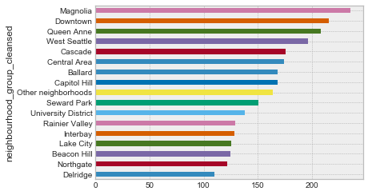

```python
loaction_price = q1_1.groupby("neighbourhood_group_cleansed").mean()["price"].sort_values()
loaction_price.plot.barh()
```

```python
loaction_price
```

```
neighbourhood_group_cleansed
Delridge               109.962025
Northgate              121.650000
Beacon Hill            124.898305
Lake City              125.208955
Interbay               128.000000
Rainier Valley         128.735849
University District    138.221311
Seward Park            150.750000
Other neighborhoods    163.741814
Capitol Hill           168.386243
Ballard                168.456522
Central Area           173.826558
Cascade                175.258427
West Seattle           196.413793
Queen Anne             207.894915
Downtown               215.526415
Magnolia               235.131148
Name: price, dtype: float64
```

```python
location_sub_c = q1_1[(q1_1["neighbourhood_group_cleansed"] == "Magnolia") |
                      (q1_1["neighbourhood_group_cleansed"] == "Downtown") |
                      (q1_1["neighbourhood_group_cleansed"] == "Queen Anne") |
                      (q1_1["neighbourhood_group_cleansed"] == "West Seattle")]

location_sub_c = location_sub_c.groupby("property_type").count()
location_sub_c["id"]/location_sub_c["id"].sum()
```

```
property_type
Apartment          0.635445
Bed & Breakfast    0.007346
Boat               0.000918
Bungalow           0.002755
Cabin              0.001837
Camper/RV          0.003673
Chalet             0.000918
Condominium        0.049587
Dorm               0.001837
House              0.252525
Loft               0.012856
Other              0.005510
Townhouse          0.022957
Treehouse          0.000918
Yurt               0.000918
Name: id, dtype: float64
```

```python
location_sub_i = q1_1[(q1_1["neighbourhood_group_cleansed"] == "Delridge") |
                      (q1_1["neighbourhood_group_cleansed"] == "Northgate") |
                      (q1_1["neighbourhood_group_cleansed"] == "Beacon Hill") |
                      (q1_1["neighbourhood_group_cleansed"] == "Lake City")]

location_sub_i = location_sub_i.groupby("property_type").count()
location_sub_i["id"]/location_sub_i["id"].sum()
```

```
property_type
Apartment          0.220930
Bed & Breakfast    0.014535
Bungalow           0.002907
Cabin              0.014535
Camper/RV          0.005814
Condominium        0.002907
House              0.671512
Loft               0.002907
Other              0.005814
Tent               0.011628
Townhouse          0.046512
Name: id, dtype: float64
```

```python
properties = q1_1["property_type"].dropna().unique()
accom = pd.DataFrame()
for prop in properties:
    accom = pd.concat([accom,
                       q1[q1_1["property_type"]==prop]["accommodates"].describe().rename(prop)],
                      axis=1)

accom.round(1)
```

|  | Apartment | House | Cabin | Condominium | Camper/RV | Bungalow | Townhouse | Loft | Boat | Bed & Breakfast | Other | Dorm | Treehouse | Yurt | Chalet | Tent |
| --- | --- | --- | --- | --- | --- | --- | --- | --- | --- | --- | --- | --- | --- | --- | --- | --- |
| 25% | 2.0 | 2.0 | 2.0 | 2.0 | 2.0 | 2.0 | 2.0 | 2.0 | 1.0 | 2.0 | 2.0 | 8.0 | 2.0 | 3.0 | 4.0 | 2.0 |
| 50% | 3.0 | 2.0 | 2.0 | 4.0 | 2.0 | 2.0 | 2.0 | 2.0 | 1.0 | 2.0 | 2.0 | 8.0 | 2.0 | 3.0 | 4.0 | 2.0 |
| 75% | 4.0 | 5.0 | 3.0 | 4.0 | 2.0 | 2.0 | 4.0 | 4.0 | 4.5 | 3.0 | 3.0 | 8.0 | 2.0 | 3.0 | 4.0 | 2.0 |
| count | 1278.0 | 1303.0 | 20.0 | 66.0 | 9.0 | 9.0 | 74.0 | 31.0 | 3.0 | 25.0 | 17.0 | 2.0 | 1.0 | 1.0 | 1.0 | 1.0 |
| max | 10.0 | 16.0 | 8.0 | 8.0 | 3.0 | 3.0 | 10.0 | 10.0 | 8.0 | 4.0 | 4.0 | 8.0 | 2.0 | 3.0 | 4.0 | 2.0 |
| mean | 3.2 | 3.6 | 2.8 | 3.5 | 2.1 | 2.1 | 3.4 | 3.1 | 3.3 | 2.2 | 2.4 | 8.0 | 2.0 | 3.0 | 4.0 | 2.0 |
| min | 1.0 | 1.0 | 2.0 | 1.0 | 2.0 | 2.0 | 1.0 | 1.0 | 1.0 | 1.0 | 1.0 | 8.0 | 2.0 | 3.0 | 4.0 | 2.0 |
| std | 1.4 | 2.4 | 1.4 | 1.6 | 0.3 | 0.3 | 2.2 | 1.7 | 4.0 | 1.0 | 1.0 | 0.0 | NaN | NaN | NaN | NaN |

```python
accom_4 = q1_1[q1_1["accommodates"] > 4].groupby("property_type").count()[["id"]]
accom_4 = accom_4.join(q1_1.groupby("property_type").count()["id"].rename("total"),how="left")
accom_4["id"].sum()/accom_4["total"].sum()
accom_4
```

| property_type | id | total |
| --- | --- | --- |
| Apartment | 221 | 1708 |
| Boat | 2 | 8 |
| Bungalow | 1 | 13 |
| Cabin | 1 | 21 |
| Condominium | 19 | 91 |
| Dorm | 2 | 2 |
| House | 476 | 1733 |
| Loft | 4 | 40 |
| Townhouse | 26 | 118 |

## Question 2: When to visit Seattle is most economy for family tourism living in airbnb?

### 1. Prepare Data

1. to observe price trend
2. to observe availability
3. price change in each property type

### 1.1 Data Gathering

#### - main data

```python
q2_calendar = calendar.copy()
q2_listing = listing.copy()

q2 = pd.merge(q2_calendar,
              q2_listing[["id","property_type"]],left_on="listing_id",right_on="id",how="left")
q2["month"] = q2["month"].astype(int)
q2["weekday"] = q2["date"].dt.weekday
```

#### - availability

> when the airbnb is not available, there is no price provided. There are 2 possible. One is out of service while the other is full booking.

```python
q2_available = q2.groupby(["listing_id","month"])["available"].agg(["count","sum"])
q2_available["full_ratio"] = 1 - (q2_available["sum"]/q2_available["count"])
q2_available = q2_available.reset_index()
q2_available = pd.merge(q2_available,q2_listing[["id","property_type"]],
                        left_on="listing_id",right_on="id", how="left")
```

### 1.2 Handle categorical and missing data

#### - main data

```python
q2_price = q2[q2["available"]]
```

```python
q2_price.info()
```

```
<class 'pandas.core.frame.DataFrame'>
Int64Index: 928844 entries, 0 to 1385579
Data columns (total 8 columns):
listing_id       928844 non-null int64
date             928844 non-null datetime64[ns]
available        928844 non-null bool
price            928844 non-null float64
month            928844 non-null int64
id               928844 non-null int64
property_type    928537 non-null object
weekday          928844 non-null int64
dtypes: bool(1), datetime64[ns](1), float64(1), int64(4), object(1)
memory usage: 57.6+ MB
```

#### - availability

```python
q2_available.info()
```

```
<class 'pandas.core.frame.DataFrame'>
Int64Index: 45816 entries, 0 to 45815
Data columns (total 7 columns):
listing_id       45816 non-null int64
month            45816 non-null int64
count            45816 non-null int64
sum              45816 non-null float64
full_ratio       45816 non-null float64
id               45816 non-null int64
property_type    45804 non-null object
dtypes: float64(2), int64(4), object(1)
memory usage: 2.8+ MB
```

### 2. Analyze, Model, and Visualize

#### **- Price distribution and trend**

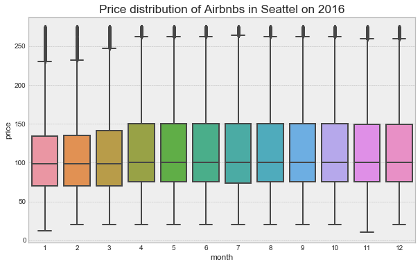

```python
fig,ax = plt.subplots(figsize=(10,6))
sns.boxplot(y="price",x="month",data=q2[q2["price"]<q2["price"].quantile(0.92)],ax=ax);
ax.set_title("Price distribution of Airbnbs in Seattel on 2016",fontsize="xx-large");
```

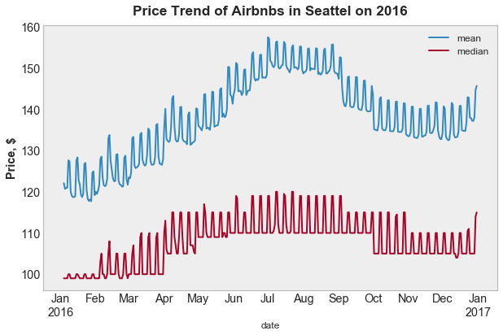

```python
fig,ax = plt.subplots(figsize=(10,6))
q2_price.groupby("date")["price"].agg(["mean","median"]).plot(ax=ax,grid=False,fontsize="x-large");
ax.legend(fontsize="large")
ax.set_ylabel("Price, $", fontsize="x-large",fontweight="bold")
plt.title("Price Trend of Airbnbs in Seattel on 2016",fontsize="xx-large",fontweight="bold",y=1.02);
plt.savefig("priceTrend.png",dpi=300,bbox_inches="tight")
```

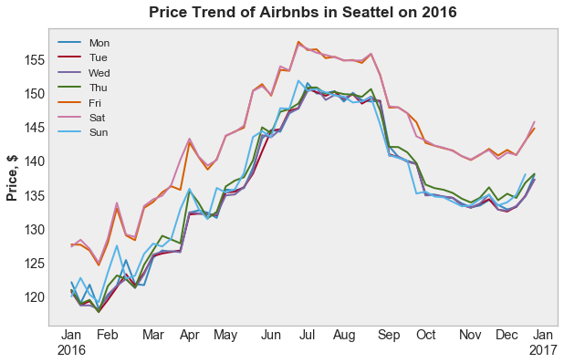

```python
fig,ax = plt.subplots(figsize=(10,6))

a = q2_price.groupby(["date","weekday"])["price"].mean().unstack()

for col in a.columns:
    a[col].dropna().plot(ax=ax,fontsize="x-large")

ax.legend(["Mon","Tue","Wed","Thu","Fri","Sat","Sun"],fontsize="large");
ax.set_xlabel("")
ax.set_ylabel("Price, $", fontsize="x-large",fontweight="bold")
ax.grid(False)

plt.title("Price Trend of Airbnbs in Seattel on 2016",fontsize="xx-large",fontweight="bold",y=1.02);
plt.savefig("priceTrend.png",dpi=300,bbox_inches="tight")
```

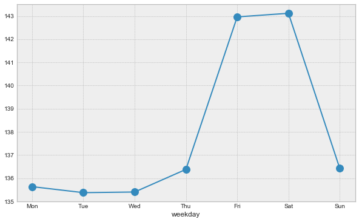

```python
fig,ax = plt.subplots(figsize=(10,6))
a.mean(axis=0).plot(ax=ax, marker="o",markersize=12);
ax.set_xticklabels(["","Mon","Tue","Wed","Thu","Fri","Sat","Sun"]);
```

#### **- Type of property and room**

```python
q2_property = q2.groupby(["property_type","month"])["price"].agg(["mean","median"]).reset_index()
q2_property = pd.melt(q2_property,id_vars=["property_type","month"],value_name="price",var_name="smooth")
```

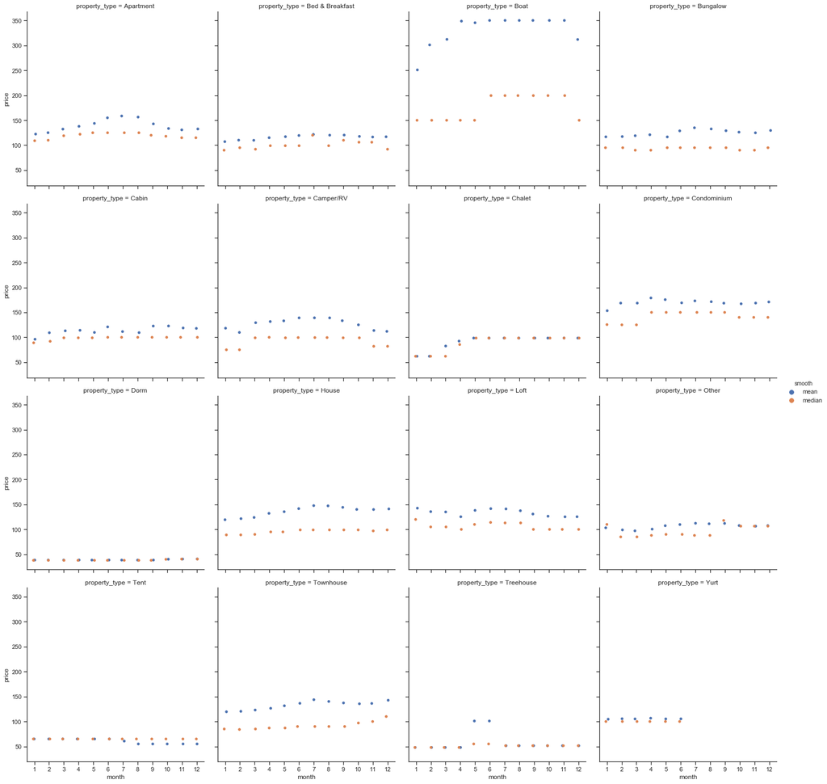

```python
sns.set(style="ticks")
sns.catplot(x="month",y="price",hue="smooth",col="property_type",
            data=q2_property,
            col_wrap=4);
```

**- availability**

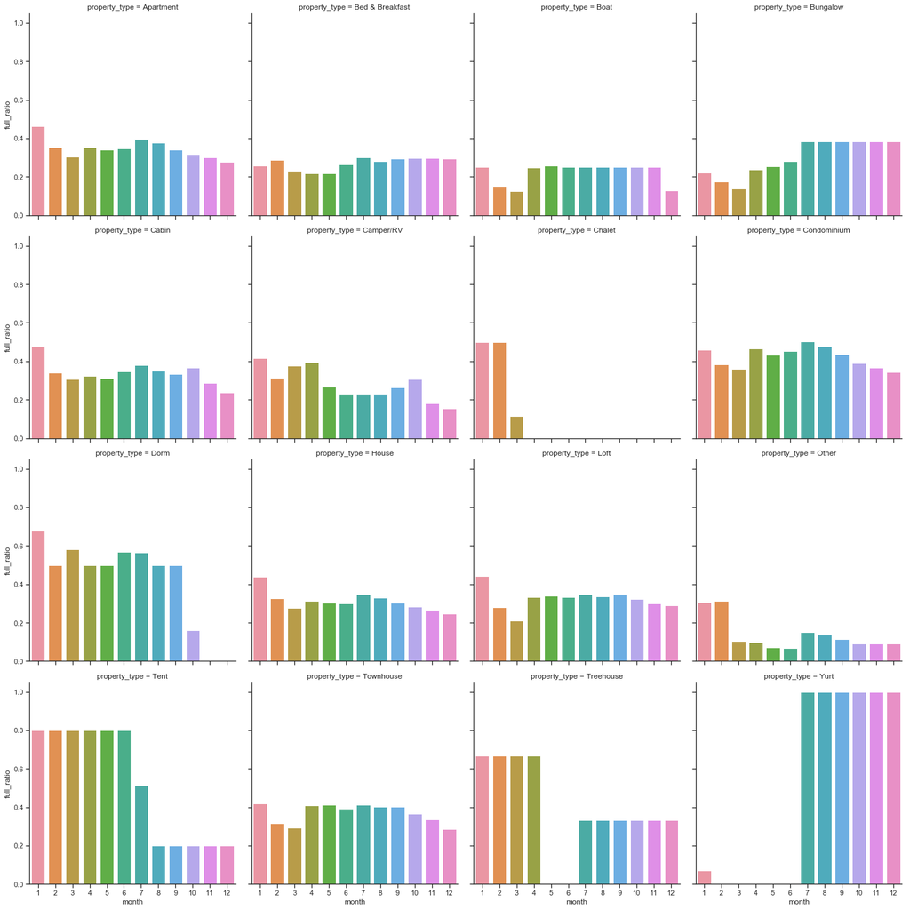

```python
q2_available_prop = q2_available.groupby(["property_type","month"])[["full_ratio"]].mean().reset_index()
q2_available_prop["month"] = q2_available_prop["month"].astype(int)
sns.catplot(x="month",y="full_ratio",col="property_type",data=q2_available_prop, kind="bar",col_wrap=4);
```

## Question 3: Are reviews helpful for choosing airbnb?

## 1. Prepare Data

### 1.1 Data Gathering

> Reviews include number of reviews and review score. I'd like to know whether reviews would affect tenant. Perhaps, full ratio may help me to figure it out. If an airbnb is always available, it's possible no tenant likes to living there.

```python
q3_reviews = listing.copy()[["id",
                             "price",
                             "availability_30",
                             "number_of_reviews",
                             "review_scores_rating",
                             "review_scores_accuracy",
                             "review_scores_cleanliness",
                             "review_scores_checkin",
                             "review_scores_communication",
                             "review_scores_location",
                             "review_scores_value",
                             "reviews_per_month"]]
```

```python
q3_availableRate = calendar.groupby("listing_id")[["available"]].mean().reset_index()
```

### 1.2 Handle categorical and missing data

```python
q3_reviews["availability_30"]=q3_reviews["availability_30"]/30
q3_reviews = q3_reviews.dropna(axis=0)
q3_reviews = pd.merge(q3_reviews,q3_availableRate, left_on="id", right_on="listing_id", how="left")
```

```python
q3_reviews["review_score"]=pd.cut(q3_reviews["review_scores_rating"],
                                  np.arange(0,101,10),
                                  labels=np.arange(10,101,10))
```

### 2. Analyze, Model, and Visualize

#### - Distribution of review_scores_rating

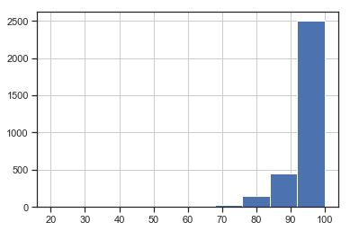

```python
q3_reviews["review_scores_rating"].hist();
```

```python
q3_reviews.groupby(["review_score"])["id"].count()/q3_reviews.shape[0]
```

```
review_score
10     0.000000
20     0.000317
30     0.000000
40     0.001267
50     0.000000
60     0.004750
70     0.005066
80     0.044965
90     0.120963
100    0.822673
Name: id, dtype: float64
```

```python
q3_reviews["review_scores_rating"].mean()
```

```
94.53894870170994
```

> most reviews had score great 90 so that it might provide limit information.

#### - relation among rating score and parts of rating score

```python
X = np.log(q3_reviews[["review_scores_accuracy",
                "review_scores_cleanliness",
                "review_scores_checkin",
                "review_scores_communication",
                "review_scores_location",
                "review_scores_value"]])
y = np.log(q3_reviews["review_scores_rating"])
```

```python
from sklearn.model_selection import train_test_split
from sklearn.metrics import r2_score
X_train, X_test, y_train, y_test = train_test_split(X,y)
```

```python
from sklearn.linear_model import LinearRegression

lr_model = LinearRegression()
lr_model = lr_model.fit(X_train, y_train)

pred = lr_model.predict(X_test)
r2_score(pred,y_test)
```

```
0.4185284531373076
```

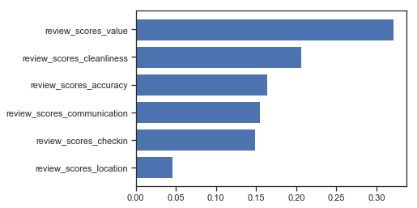

```python
ind = np.argsort(lr_model.coef_)
plt.barh(y = range(X.shape[1]), width = lr_model.coef_[ind]);
plt.yticks(range(X.shape[1]), X.columns[ind]);
```

```python
from sklearn.ensemble import RandomForestRegressor
rf_model = RandomForestRegressor()
rf_model = rf_model.fit(X_train, y_train)

pred = rf_model.predict(X_test)
r2_score(pred,y_test)
```

```
0.30851872546381287
```

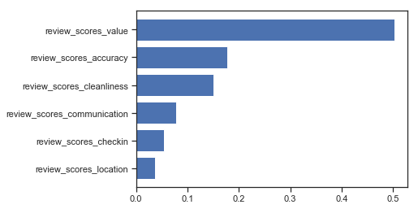

```python
ind = np.argsort(rf_model.feature_importances_)
plt.barh(y = range(X.shape[1]), width = rf_model.feature_importances_[ind])
plt.yticks(range(X.shape[1]),X.columns[ind]);
```

> Reviews score for airbnb is combined by 6 independent parts. They were accuracy, cleanliness, checkin, communication, location and value. However, they didn't equally impact the results of the overall score. I set up 2 models to appraise the feature important and achieve similar conclusions. Value is the most important feature and the location is the least.

#### - price and rating score

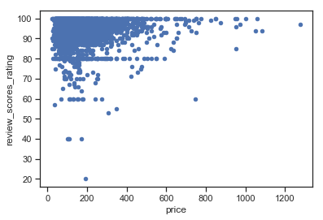

```python
q3_reviews.plot.scatter(x="price",y="review_scores_rating");
```

> As we known, customers who would like to living airbnb were price sensitive. Most low score occurs where the price is lower than \$400.

#### - price and number of ratings

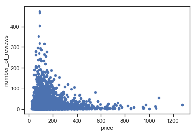

```python
q3_reviews.plot.scatter(x="price",y="number_of_reviews");
```

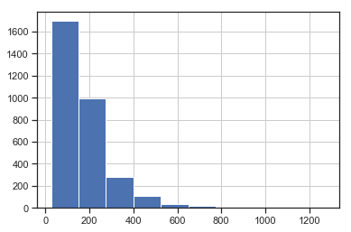

```python
q3_reviews["price"].hist()
```

> price of most airbnb is lower than \$200, reviews concentrated in these airbnbs.

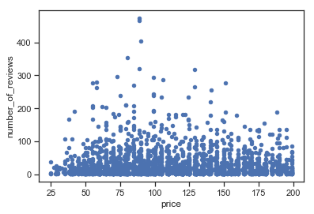

```python
subset = q3_reviews[q3_reviews["price"]<200]
subset.plot.scatter(x="price",y="number_of_reviews");
```

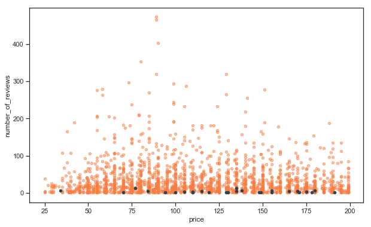

```python
fig,ax = plt.subplots(figsize=(10,6))
subset[subset["review_score"]>=80].plot.scatter(x="price",y="number_of_reviews",color="#f87d42",ax=ax,alpha=0.5);
subset[subset["review_score"]<80].plot.scatter(x="price",y="number_of_reviews",color="#2b4353",ax=ax);
```

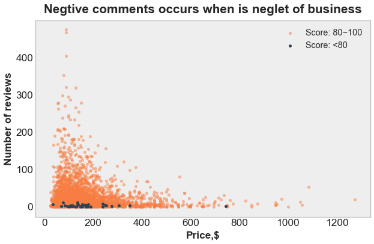

```python
plt.style.use("bmh")
fig,ax = plt.subplots(figsize=(10,6))
q3_reviews[q3_reviews["review_score"]>=80].plot.scatter(x="price",y="number_of_reviews",
                                                        color="#f87d42",fontsize="x-large",
                                                        ax=ax,alpha=0.5);
q3_reviews[q3_reviews["review_score"]<80].plot.scatter(x="price",y="number_of_reviews",
                                                       color="#2b4353",ax=ax);
ax.set_ylabel("Number of reviews",fontsize="x-large",fontweight="bold")
ax.set_xlabel("Price,$",fontsize="x-large",fontweight="bold")
ax.set_title("Negtive comments occurs when is neglet of business",fontsize="xx-large",fontweight="bold",y=1.02)
ax.legend(["Score: 80~100","Score: <80"],fontsize="large")
plt.grid(False)
plt.savefig("review.png",dpi=300,bbox_inches="tight")
```

> lower review score, less reviews.

#### - review score and availability

```python
q3_reviews[["review_scores_rating","available"]].corr()
```

|  | review_scores_rating | available |
| --- | --- | --- |
| review_scores_rating | 1.000000 | -0.036849 |
| available | -0.036849 | 1.000000 |

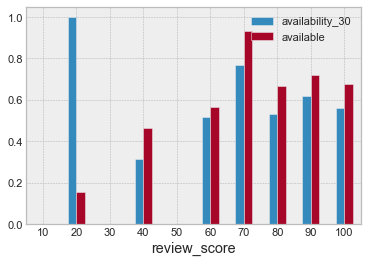

```python
q3_reviews.groupby("review_score")[["availability_30","available"]].mean().plot.bar(rot=0)
```